# Simulation of Empirical Bayesian Methods

This post and the following posts are a simplification of a series of posts by [David Robinson](http://varianceexplained.org/r/simulation-bayes-baseball/)

Even if we assume each player has a “true” batting average as our model suggests, we don’t know it, so we can’t see if our methods estimated it accurately. For example, we think that empirical Bayes shrinkage gets closer to the true probabilities than raw batting averages do, but we can’t actually measure the mean-squared error. This means we can’t test our methods, or examine when they work well and when they don’t.

In this post we’ll simulate some fake batting average data, which will let us know the true probabilities for each player, then examine how close our statistical methods get to the true solution. Simulation is a universally useful way to test a statistical method, to build intuition about its mathematical properies, and to gain confidence that we can trust its results

```r
library(knitr)
opts_chunk$set(message = FALSE, warning = FALSE)

library(scales)
library(ggplot2)
theme_set(theme_bw())
```

## Setup

```r
library(Lahman)
library(dplyr)
library(tidyr)

# Grab career batting average of non-pitchers
# (allow players that have pitched <= 3 games, like Ty Cobb)
pitchers <- Pitching %>%
  group_by(playerID) %>%
  summarize(gamesPitched = sum(G)) %>%
  filter(gamesPitched > 3)

# include the "bats" (handedness) and "year" column for later
career <- Batting %>%
  filter(AB > 0) %>%
  anti_join(pitchers, by = "playerID") %>%
  group_by(playerID) %>%
  summarize(H = sum(H), AB = sum(AB))
```

## Choosing a distribution of p and AB

In the beta-binomial model we’ve been using for most of these posts, there are two values for each player $i$:

$$p_i \sim \mbox{Beta}(\alpha_0, \beta_0)$$

$$H_i \sim \mbox{Binom}(\mbox{AB}_i, p_i)$$

$\alpha_0;\beta_0$ are “hyperparameters”: two unobserved values that describe the entire distribution. $p_i$ is the true batting average for each player- we don’t observe this, but it’s the “right answer” for each batter that we’re trying to estimate. $\mbox{AB}_i$ is the number of at-bats the player had, which is observed. (You might recall we had a more complicated model in the beta-binomial regression post that had $p_i$ depend on $AB_i$: we’ll get back to that).

Our approach is going to be to pick some “true” $\alpha_0;\beta_0$, then simulate $p_i$ for each player. Since we’re just picking any $\alpha_0;\beta_0$ to start with, we may as well estimate them from our data, since we know those are plausible values (though if we wanted to be more thorough, we could try a few other values and see how our accuracy changes).

To do this estimation, we can use our new ebbr package to fit the empirical Bayes prior.

```r
library(ebbr)
prior <- career %>%
  ebb_fit_prior(H, AB)

prior
```

```
## Empirical Bayes binomial fit with method mle
## Parameters:
## # A tibble: 1 x 2
##   alpha  beta
##   <dbl> <dbl>
## 1  72.7   217
```

These two hyperparameters are all we need to simulate a few thousand values of $p_i$, using the rbeta function:

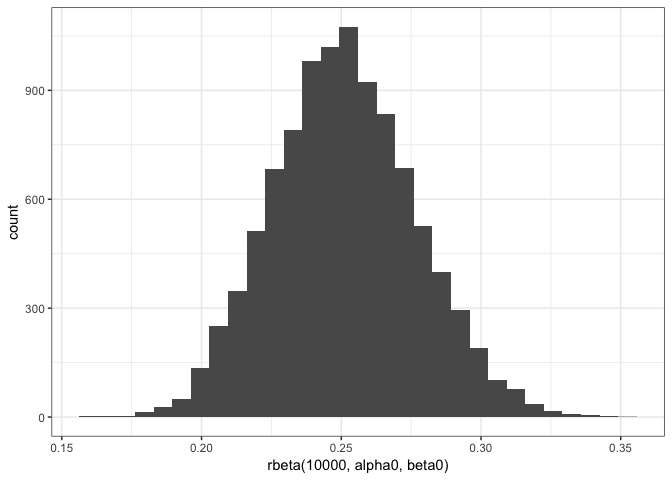

```r
alpha0 <- tidy(prior)$alpha
beta0 <- tidy(prior)$beta

qplot(rbeta(10000, alpha0, beta0))
```

There’s another component to this model: $\mbox{AB}_i$, the distribution of the number of at-bats. This is a much more unusual distribution:

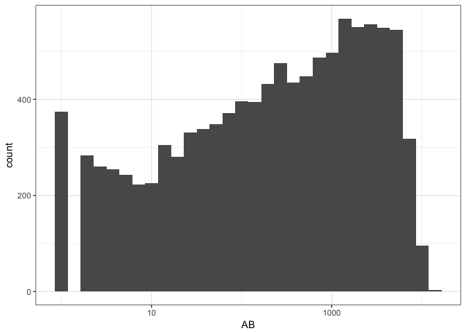

```r
ggplot(career, aes(AB)) +
  geom_histogram() +
  scale_x_log10()
```

The good news is, we don’t need to simulate these $\mbox{AB}_{i}$ values, since we’re not trying to estimate them with empirical Bayes. We can just use the observed values we have! (In a different study, we may be interested in how the success of empirical Bayes depends on the distribution of the $n$s).

To reacp, we will:

- Estimate $\alpha_0;\beta_0$, which works because the parameters are not observed, but there are only a few and we can predict them with confidence.
- Simulate $p_i$, based on a beta distribution, so that we can test our ability to estimate them.
- Use observed $\mbox{AB}_i$, since we know the true values and we might as well.

## Shrinkage on Simulated Data

The beta-binomial model is easy to simulate, with applications of the `rbeta` and `rbinom` functions:

```r
# always set a seed when simulating
set.seed(2017)

career_sim <- career %>%
  mutate(p = rbeta(n(), alpha0, beta0),
         H = rbinom(n(), AB, p))

career_sim
```

```
## # A tibble: 10,590 x 4
##    playerID      H    AB     p
##    <chr>     <int> <int> <dbl>
##  1 aaronha01  3661 12364 0.299
##  2 aaronto01   229   944 0.249
##  3 abadan01      2    21 0.273
##  4 abadijo01     6    49 0.198
##  5 abbated01   746  3044 0.249
##  6 abbeych01   445  1751 0.264
##  7 abbotda01     2     7 0.191
##  8 abbotfr01   122   513 0.251
##  9 abbotje01   154   596 0.243
## 10 abbotku01   583  2044 0.261
## # ... with 10,580 more rows
```

Just like that, we’ve generated a “true” $p_i$ for each player, and then a new value of $H$ based on it. (This means there is no relationship between how good a particular player is in our simulation and how good they are in reality)

Our working theory has been that our raw $H / \mbox{AB}$ estimates have had a large amount of noise when $\mbox{AB}$ is small, and that empirical Bayes helps moderate it. Now, since we know the true value of $p_i$ for each player, we can finally examine whether that’s true: and we can see what the empirical Bayes method is giving up as well.

Let’s visualize the true values of $p_i$ versus the estimates, which we’ll call $\hat{p_i}$, using either raw estimation or empirical Bayes shrinkage. (Again, we couldn’t have made this plot with the real data since we don’t know the true $p_i$: it’s possible only in our simulation).

```r
career_sim_eb <- career_sim %>%
  add_ebb_estimate(H, AB)

career_sim_gathered <- career_sim_eb %>%
  rename(Shrunken = .fitted, Raw = .raw) %>%
  gather(type, estimate, Shrunken, Raw)
```

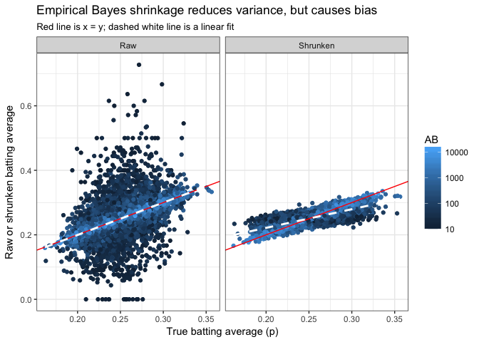

```r
career_sim_gathered %>%
  filter(AB >= 10) %>%
  ggplot(aes(p, estimate, color = AB)) +
  geom_point() +
  geom_abline(color = "red") +
  geom_smooth(method = "lm", color = "white", lty = 2, se = FALSE) +
  scale_color_continuous(trans = "log", breaks = c(10, 100, 1000, 10000)) +
  facet_wrap(~ type) +
  labs(x = "True batting average (p)",
       y = "Raw or shrunken batting average",
       title = "Empirical Bayes shrinkage reduces variance, but causes bias",
       subtitle = "Red line is x = y; dashed white line is a linear fit")
```

Our method works: the Raw (H / AB) estimates have a lot more noise than the shrunken estimates, just as we expected. (We filtered out cases where $AB < 10$ in this graph: if we hadn’t, the difference would have been even starker).

However, notice the dashed line representing the best-fit slope. One property that we’d prefer an estimate to have is that it’s equally likely to be an overestimate or an underestimate (that is, that $E[\hat{p}]=p$), and that’s true for the raw average. However, the shrunken estimate tends to be too high for low values of $p$, and too low for high values of $p$. The empirical Bayes method has introduced bias into our estimate, in exchange for drastically reducing the variance. This is a classic tradeoff in statistics and machine learning.

## Mean-squared error and bias relative to AB

Typically, when statisticians are facing a tradeoff between bias and variance, we use mean squared error (or MSE) as a balance, which is computed as $\mbox{MSE}=\frac{1}{n}\sum_{1}^{n}(p-\hat{p})^2$. We can easily compute that for both the raw and shrunken methods:

```r
career_sim_gathered %>%
  group_by(type) %>%
  summarize(mse = mean((estimate - p) ^ 2))
```

```
## # A tibble: 2 x 2
##   type          mse
##   <chr>       <dbl>
## 1 Raw      0.0145
## 2 Shrunken 0.000335
```

The MSE of the shrunken estimate was much lower than the raw estimate, as we probably could have guessed by eyeballing the graph. So by this standard, the method succeeded!

We’ve seen in the graph how the variance depends on $\mbox{AB}$, so we may want to compute the MSE within particular bins. We should use logarithmic bins (`10 ^ (round(log10(AB))`) is a handy shortcut).

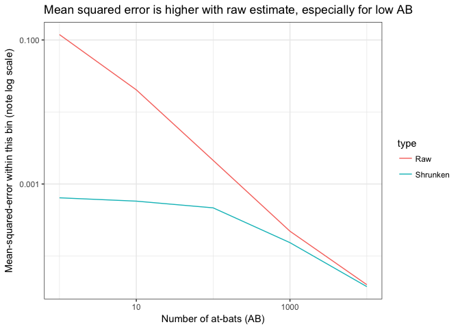

```r
metric_by_bin <- career_sim_gathered %>%
  group_by(type, AB = 10 ^ (round(log10(AB)))) %>%
  summarize(mse = mean((estimate - p) ^ 2))

ggplot(metric_by_bin, aes(AB, mse, color = type)) +
  geom_line() +
  scale_x_log10() +
  scale_y_log10() +
  labs(x = "Number of at-bats (AB)",
       y = "Mean-squared-error within this bin (note log scale)",
       title = "Mean squared error is higher with raw estimate, especially for low AB")
```

*Was code here but did not work, so was removed..*

Another way to visualize how this tradeoff between bias and variance happens for varying AB is to recreate the above graph of the true batting average versus the estimate, this time binning by $AB$.

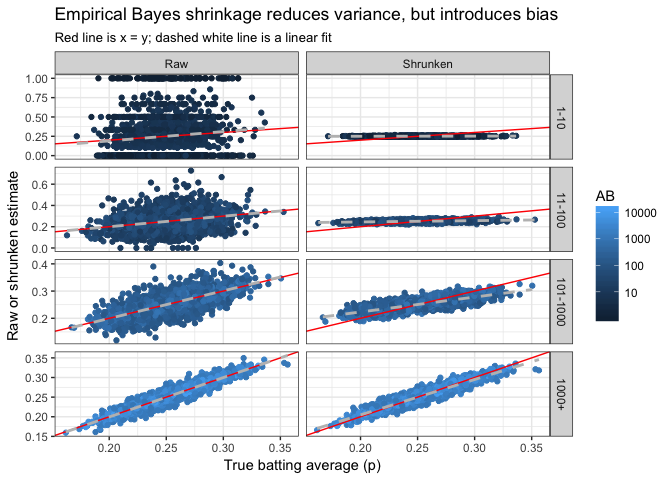

```r
career_sim_gathered %>%
  mutate(ab_bin = cut(AB, c(0, 10, 100, 1000, Inf),
                      labels = c("1-10", "11-100", "101-1000", "1000+"))) %>%
  ggplot(aes(p, estimate, color = AB)) +
  geom_point() +
  geom_abline(color = "red") +
  geom_smooth(method = "lm", color = "gray", lty = 2, se = FALSE) +
  scale_color_continuous(trans = "log", breaks = c(10, 100, 1000, 10000)) +
  facet_grid(ab_bin ~ type, scales = "free_y") +
  labs(x = "True batting average (p)",
       y = "Raw or shrunken estimate",
       title = "Empirical Bayes shrinkage reduces variance, but introduces bias",
       subtitle = "Red line is x = y; dashed white line is a linear fit")
```

Notice how the variance around the true (red) line shrinks in the raw estimate, and the bias (the flatness of the gray dashed line) in the shrunken estimate decreases, until both look quite similar in the 1000+ bin.

## Credible intervals

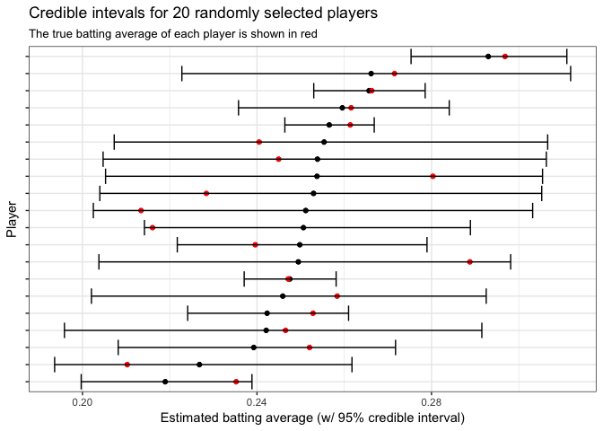

```r
set.seed(2017)

career_sim_eb %>%
  sample_n(20) %>%
  mutate(playerID = reorder(playerID, .fitted)) %>%
  ggplot(aes(.fitted, playerID)) +
  geom_point() +
  geom_point(aes(x = p), color = "red") +
  geom_errorbarh(aes(xmin = .low, xmax = .high)) +
  theme(axis.text.y = element_blank()) +
  labs(x = "Estimated batting average (w/ 95% credible interval)",
       y = "Player",
       title = "Credible intevals for 20 randomly selected players",
       subtitle = "The true batting average of each player is shown in red")
```

```r
career_sim_eb %>%
  summarize(coverage = mean(.low <= p & p <= .high))
```

```
## # A tibble: 1 x 1
##   coverage
##      <dbl>
## 1    0.951
```

We could also have set the threshold of the credible interval to 90%, or 75%. Does the probability that the parameter is contained within the interval change accordingly?

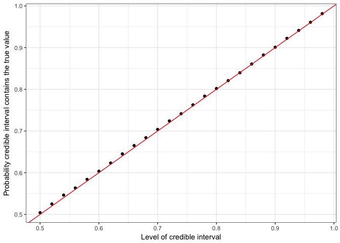

```r
library(purrr)

# fit the prior once
sim_prior <- ebb_fit_prior(career_sim, H, AB)

# find the coverage probability for each level
estimate_by_cred_level <- data_frame(level = seq(.5, .98, .02)) %>%
  unnest(map(level, ~ augment(sim_prior, career_sim, cred_level = .)))

estimate_by_cred_level %>%
  group_by(level) %>%
  mutate(cover = .low <= p & p <= .high) %>%
  summarize(coverage = mean(cover)) %>%
  ggplot(aes(level, coverage)) +
  geom_point() +
  geom_abline(color = "red") +
  labs(x = "Level of credible interval",
       y = "Probability credible interval contains the true value")
```

Notice that the probability (the points) hugs the red x=y line almost precisely. This shows that these per-observation credible intervals are generally well-calibrated: if you ask for a X% credible interval, you get a region that contains the true parameter about X% of the time.

## FDR control

In another post we considered the problem of Bayesian hypothesis testing and FDR control. In particular, we considered the problem of constructing a list of players whose true batting average was above .300, and controlling such that only (say) 10% of the players on the list were included incorrectly.

The q-value, which controls FDR, can be calculated with the `add_ebb_prop_test` function:

```r
pt <- career_sim_eb %>%
  add_ebb_prop_test(.3, sort = TRUE)

# Control for FDR of 10%
hall_of_fame <- pt %>%
  filter(.qvalue <= .1)
nrow(hall_of_fame)
```

```
## [1] 78
```

If the FDR control were successful, we’d expect 10% of the true batting averages (p) to be false discoveries, and therefore below .300. Did it work?

```r
mean(hall_of_fame$p < .3)
```

```
## [1] 0.1282051
```

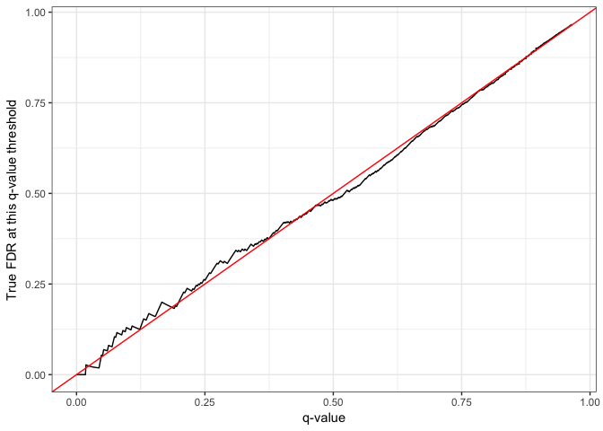

```r
pt %>%
  mutate(true_fdr = cummean(p < .3)) %>%
  ggplot(aes(.qvalue, true_fdr)) +
  geom_line() +
  geom_abline(color = "red") +
  labs(x = "q-value",
       y = "True FDR at this q-value threshold")
```

Notice that the FDR was often a little bit higher than we aimed for with the q-value, which could be due to random noise. Later in this post, we’ll perform many replications of this simulation and confirm whether the FDR method was successful on average.

## Beta-binomial regression

Most simulation analyses start with a simple model, than gradually add complications. In a post on beta-binomial regression, we discovered that there is a relationship between $\mbox{AB}_i$ and the true batting average $p_i$ that we need to incorporate into our model. Let’s add that complication to our simulation, and see if the method we used to account for it actually works.

The model described in that post had three hyperparameters: $\mu_0$, $\mu_{\mbox{AB}}$ and $\sigma_0$. Then each of the probabilities $p_i$ was computed as:

$$\mu_i = \mu_0 + \mu_{\mbox{AB}} \cdot \log(\mbox{AB})$$

$$\alpha_{0,i} = \mu_i / \sigma_0$$

$$\beta_{0,i} = (1 - \mu_i) / \sigma_0$$

$$p_i \sim \mbox{Beta}(\alpha_{0,i}, \beta_{0,i})$$

$$H_i \sim \mbox{Binom}(\mbox{AB}_i, p_i)$$

Much as we estimated $\alpha_0$ and $\beta_0$ from the data before using them in the simulation, we would estimate $\mu_0$, $\mu_\mbox{AB}$, and $\sigma_0$ from the data:

```r
bb_reg <- career %>%
  ebb_fit_prior(H, AB, method = "gamlss", mu_predictors = ~ log10(AB))

tidy(bb_reg)
```

```
## # A tibble: 3 x 6
##   parameter term        estimate std.error statistic p.value
##   <fct>     <chr>          <dbl>     <dbl>     <dbl>   <dbl>
## 1 mu        (Intercept)   -1.68    0.00896    -188         0
## 2 mu        log10(AB)      0.191   0.00277      69.1       0
## 3 sigma     (Intercept)   -6.30    0.0229     -275         0
```

It turns out this step is pretty easy with the `augment` method of the beta-binomial prior.

```r
set.seed(2017)

career_sim_ab <- augment(bb_reg, career) %>%
  dplyr::select(playerID, AB, true_alpha0 = .alpha0, true_beta0 = .beta0) %>%
  mutate(p = rbeta(n(), true_alpha0, true_beta0),
         H = rbinom(n(), AB, p))
```

### Performance of beta-binomial regression method

First question: are we able to extract the right hyperparameters through beta-binomial regression? We’ll fit the prior and then compare:

```r
career_ab_prior <- career_sim_ab %>%
  ebb_fit_prior(H, AB, method = "gamlss", mu_predictors = ~ log10(AB))
```

```r
tidy(bb_reg)
```

```
## # A tibble: 3 x 6
##   parameter term        estimate std.error statistic p.value
##   <fct>     <chr>          <dbl>     <dbl>     <dbl>   <dbl>
## 1 mu        (Intercept)   -1.68    0.00896    -188         0
## 2 mu        log10(AB)      0.191   0.00277      69.1       0
## 3 sigma     (Intercept)   -6.30    0.0229     -275         0
```

```r
tidy(career_ab_prior)
```

```
## # A tibble: 3 x 6
##   parameter term        estimate std.error statistic p.value
##   <fct>     <chr>          <dbl>     <dbl>     <dbl>   <dbl>
## 1 mu        (Intercept)   -1.70    0.00893    -190         0
## 2 mu        log10(AB)      0.194   0.00276      70.4       0
## 3 sigma     (Intercept)   -6.31    0.0260     -243         0
```

That’s sure pretty close! It looks like beta-binomial regression was able to estimate the true parameters accurately, which suggests the resulting prior (which depends on $\mbox{AB}_i$) will be accurate.

How did this prior, which depends on $AB$, affect our shrunken estimates? Again, since we’re working from a simulation we can compare the true values to the estimates, and do so within each model.

```r
career_flat_prior <- career_sim_ab %>%
  ebb_fit_prior(H, AB)
```

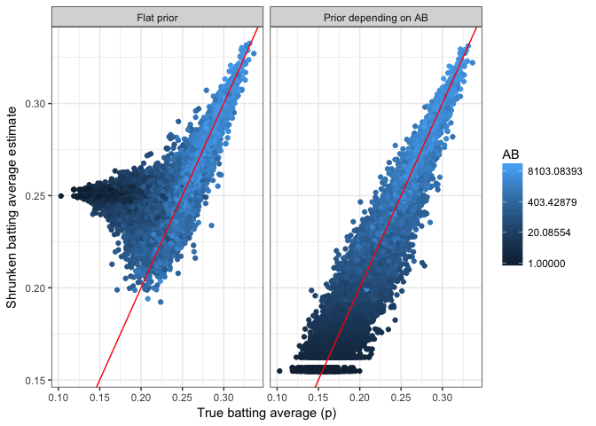

```r
data_frame(method = c("Flat prior", "Prior depending on AB"),
           model = list(career_flat_prior, career_ab_prior)) %>%
  unnest(map(model, augment, data = career_sim_ab)) %>%
  ggplot(aes(p, .fitted, color = AB)) +
  geom_point() +
  scale_color_continuous(trans = "log") +
  geom_abline(color = "red") +
  facet_wrap(~ method) +
  labs(x = "True batting average (p)",
       y = "Shrunken batting average estimate")
```

Look at the bias when we don’t take the AB to batting average relationship into account: batters with low AB and low averages were universally overestimated. This is exactly the issue we had expected in the beta-binomial regression post:

> Since low-AB batters are getting overestimated, and high-AB batters are staying where they are, we’re working with a biased estimate that is systematically overestimating batter ability.

If you’re interested, you could take this more complex model and perform the same examinations of credible intervals and priors that we did for the simple model. (Indeed, you could incorporate some of the other trends that could affect your prior, such as year and handedness, that were considered in our hierarchical model).

## Replications

So far, we ran a single simulation of our players’ batting averages, used it to perform estimation, and then examined whether our results were accurate. This is a valuable way to sanity-check the accuracy of the empirical Bayes method.

```r
set.seed(2017)

sim_replications <- career %>%
  crossing(replication = 1:50) %>%
  mutate(p = rbeta(n(), alpha0, beta0),
         H = rbinom(n(), AB, p))

sim_replications
```

```
## # A tibble: 529,500 x 5
##    playerID      H    AB replication     p
##    <chr>     <int> <int>       <int> <dbl>
##  1 aaronha01  3736 12364           1 0.299
##  2 aaronha01  3079 12364           2 0.249
##  3 aaronha01  3323 12364           3 0.273
##  4 aaronha01  2405 12364           4 0.198
##  5 aaronha01  3109 12364           5 0.249
##  6 aaronha01  3283 12364           6 0.264
##  7 aaronha01  2353 12364           7 0.191
##  8 aaronha01  3053 12364           8 0.251
##  9 aaronha01  3043 12364           9 0.243
## 10 aaronha01  3268 12364          10 0.261
## # ... with 529,490 more rows
```

```r
sim_replication_models <- sim_replications %>%
  nest(-replication) %>%
  mutate(prior = map(data, ~ ebb_fit_prior(., H, AB)))
```

## Estimations of prior parameters

```r
sim_replication_priors <- sim_replication_models %>%
  unnest(map(prior, tidy), .drop = TRUE)

sim_replication_priors
```

```
## # A tibble: 50 x 4
##    replication alpha  beta  mean
##          <int> <dbl> <dbl> <dbl>
##  1           1  69.0   206 0.251
##  2           2  72.5   216 0.252
##  3           3  72.7   217 0.250
##  4           4  74.3   222 0.251
##  5           5  71.9   215 0.250
##  6           6  71.8   214 0.251
##  7           7  72.7   217 0.251
##  8           8  71.3   213 0.251
##  9           9  75.9   227 0.251
## 10          10  71.5   213 0.251
## # ... with 40 more rows
```

Much like our earlier individual simulation, it looks like most of these are pretty close to each other, and to the true $\alpha_0$ and $\beta_0$. We could visualize to confirm:

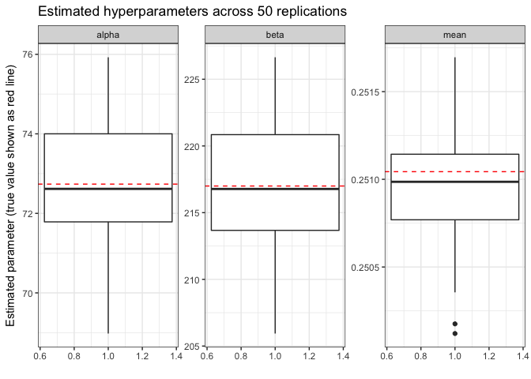

```r
true_values <- data_frame(parameter = c("alpha", "beta", "mean"),
                          true = c(alpha0, beta0, alpha0 / (alpha0 + beta0)))

sim_replication_priors %>%
  gather(parameter, value, -replication) %>%
  inner_join(true_values, by = "parameter") %>%
  ggplot(aes(1, value)) +
  geom_boxplot() +
  geom_hline(aes(yintercept = true), color = "red", lty = 2) +
  facet_wrap(~ parameter, scales = "free_y") +
  labs(x = "",
       y = "Estimated parameter (true value shown as red line)",
       title = "Estimated hyperparameters across 50 replications")
```

Our accuracy gives us confidence in the empirical Bayesian approach for this problem: we have enough data that we can feel good about estimating the hyperparameters from the data, and then using those hyperparameters as our prior.

### Estimates, intervals, and hypothesis testing across replications

Now that we’ve seen that the prior parameters are generally estimated accurately, we can examine whether the empirical Bayes shrinkage and credible intervals worked on average.

One of the first metrics we examined in the simulation was the mean squared error between the true. Did we just get lucky with that run?

```r
sim_replication_au <- sim_replication_models %>%
  unnest(map2(prior, data, augment))
```

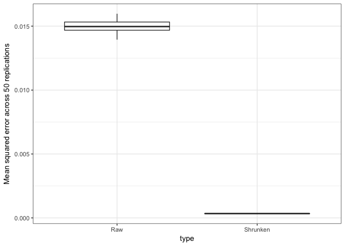

```r
sim_replication_mse <- sim_replication_au %>%
  rename(Raw = .raw, Shrunken = .fitted) %>%
  gather(type, estimate, Raw, Shrunken) %>%
  group_by(type, replication) %>%
  summarize(mse = mean((estimate - p) ^ 2))

ggplot(sim_replication_mse, aes(type, mse)) +
  geom_boxplot() +
  ylab("Mean squared error across 50 replications")
```

No, it looks like the MSE was always much lower than the raw estimates. This is a good sign: even in 50 examples, it never fails “catastrophically” and gives terrible estimates. This is not true of all methods!

We earlier saw that the credible intervals had good coverage probabilities: is this usually true?

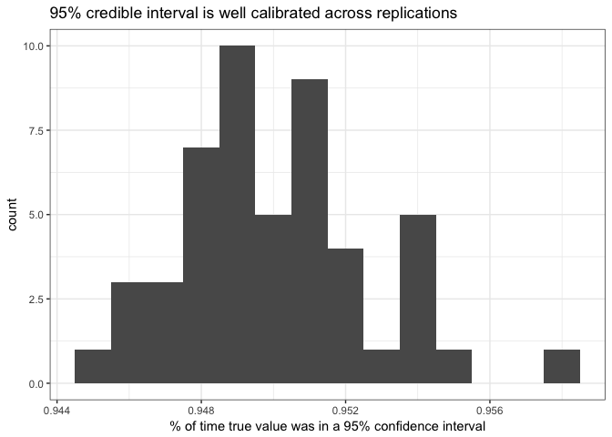

```r
sim_replication_au %>%
  mutate(cover = .low <= p & p <= .high) %>%
  group_by(replication) %>%
  summarize(coverage = mean(cover)) %>%
  ggplot(aes(coverage)) +
  geom_histogram(binwidth = .001) +
  labs(x = "% of time true value was in a 95% confidence interval",
       title = "95% credible interval is well calibrated across replications")
```

We earlier created a plot that compares credibility level to the % of intervals containing the true parameter. We can now recreate that plot, but do it across all fifty replications:

```r
sim_replication_intervals <- sim_replication_models %>%
  crossing(cred_level = c(seq(.5, .9, .05), .95)) %>%
  unnest(pmap(list(prior, data, cred_level = cred_level), augment)) %>%
  dplyr::select(replication, cred_level, p, .low, .high)
```

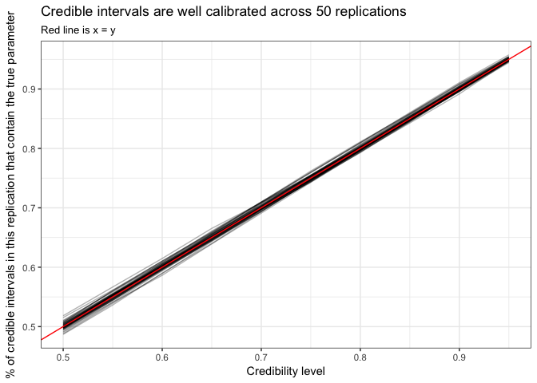

```r
sim_replication_intervals %>%
  mutate(cover = .low <= p & p <= .high) %>%
  group_by(replication, cred_level) %>%
  summarize(coverage = mean(cover)) %>%
  ggplot(aes(cred_level, coverage, group = replication)) +
  geom_line(alpha = .3) +
  geom_abline(color = "red") +
  labs(x = "Credibility level",
       y = "% of credible intervals in this replication that contain the true parameter",
       title = "Credible intervals are well calibrated across 50 replications",
       subtitle = "Red line is x = y")
```

Each of these lines is one replication tracing from a “50% credible interval” to a “95% credible interval”: since all the lines are close to the red $x=y$ line, we can see that an X% credible interval contains the true value about X% of the time. This is an important lesson of tidy simulations: whenever you can make a plot to check one simulation to check accuracy or calibration, you can also recreate the plot across many replications.

We can also examine our method for false discovery rate control, and see whether we can trust a q-value of (say) .05 to keep the FDR below 5%. The approach is similar to the one for credible interval coverage: group by each replication, then perform the same analysis we did on a single replication.

```r
sim_replication_prop_tests <- sim_replication_au %>%
  nest(-replication) %>%
  unnest(map(data, add_ebb_prop_test, threshold = .3, sort = TRUE))
```

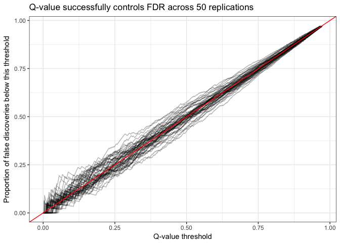

```r
sim_replication_prop_tests %>%
  group_by(replication) %>%
  mutate(fdr = cummean(p < .3)) %>%
  ggplot(aes(.qvalue, fdr, group = replication)) +
  geom_line(alpha = .3) +
  geom_abline(color = "red") +
  labs(x = "Q-value threshold",
       y = "Proportion of false discoveries below this threshold",
       title = "Q-value successfully controls FDR across 50 replications")
```

Each of these lines represents a replication tracing along every possible q-value threshold. We see that the proportion of false discoveries below a q-value is sometimes higher than the q-value promises, and sometimes lower. That’s OK: the promise of FDR control isn’t that the false discovery rate will always be exactly 5% (that would be impossible due to random noise), but that it would be on average.

These replications are just a start in terms of the random simulations we could perform to examine the method. For example, we could have varied the size of each replication (by randomly subsampling batters out of our total). Would our method still have been accurate if we had only 1,000 batters, or 100? We could have varied the algorithm used to estimate our hyperparameters: what if we’d used the (much faster) method of moments to compute the beta prior, rather than maximum likelihod? I encourage you to explore other simulations you might be interested in.